# {SLmetrics}: Classification tasks

Training a {lightgbm} classifier on the Glass dataset and evaluating it with {SLmetrics}

```r
# load libraries
library(SLmetrics)
```

In this vignette, we will demonstrate how to use [{SLmetrics}](https://github.com/serkor1/SLmetrics) with [{lightgbm}](https://github.com/microsoft/LightGBM) for classification tasks.

> **Prerequisite:** Familiarity with [{lightgbm}](https://github.com/microsoft/LightGBM) and the general AI/ML-workflow is assumed.

We will use the [Glass](https://archive.ics.uci.edu/dataset/42/glass+identification) dataset, made available via [{mlbench}](https://cran.r-project.org/package=mlbench), as an example throughout this vignette.

## Setup

In this section, we setup the essential the workflow for using [{SLmetrics}](https://github.com/serkor1/SLmetrics) with [{lightgbm}](https://github.com/microsoft/LightGBM).

### The data

```r
# 1) load data
# from {mlbench}
data("Glass", package = "mlbench")
```

```r
# 1.1) define the features
# and outcomes
outcome  <- c("Type")
features <- setdiff(x = colnames(Glass), y = outcome)

# 2) split data in training
# and test

# 2.1) set seed for
# for reproducibility
set.seed(1903)

# 2.2) exttract
# indices with a simple
# 80/20 split
index <- sample(1:nrow(Glass), size = 0.8 * nrow(Glass))

# 1.1) extract training
# data and construct
# as lgb.Dataset
train <- Glass[index,]
dtrain <- lightgbm::lgb.Dataset(
    data  = data.matrix(train[,features]),
    label = train$Type
)
# 1.2) extract test
# data
test <- Glass[-index,]


# 1.2.1) extract actual
# values and constuct
# as.factor for {SLmetrics}
# methods
actual <- as.factor(
    test$Type
)

# 1.2.2) construct as data.matrix
# for predict method
test <- data.matrix(
    test[,features]
)
```

### Setting up parameters

```r
# 1) define parameters
# across the vignette
parameters <- list(
    objective     = "multiclass",
    num_leaves    = 4L,
    learning_rate = 0.1,
    num_class     = 8
)
```

### Evaluation function: F score

As the custom evaluation function we use the $F_{score}$ with $\beta = 2$ to emphasize that recall is more imporant than precision. The function is defined as,

$$f_\beta = (1 + \beta^2) \cdot \frac{precision \cdot recall}{(\beta^2 \cdot precision) + recall}$$

The `fbeta()`-function returns a vector of scores for each class. We want to maximize the micro-average.

```r
# 1) define the custom
# evaluation metric
eval_fbeta <- function(
    dtrain,
    preds) {

        # 1) extract values
        actual    <- as.factor(dtrain)
        predicted <- lightgbm::get_field(preds, "label")
        value     <- fbeta(
            actual    = actual,
            predicted = predicted,
            beta      = 2,
            # Use micro-averaging to account
            # for class imbalances
            micro     = TRUE
        )

        # 2) construnct output
        # list
        list(
            name          = "fbeta",
            value         = value,
            higher_better = TRUE
        )

}
```

## Training model

We train the model using the `lgb.train()`-function,

```r
model <- lightgbm::lgb.train(
    params  = parameters,
    data    = dtrain,
    nrounds = 10L,
    eval    = eval_fbeta,
    verbose = -1
)
```

## Performance Evaluation

### Classification

We extract the predicted classes using the `predict()`-function,

```r
# 1) prediction
# from the model
predicted <- as.factor(
    predict(
        model,
        newdata = test,
        type = "class"
    )
)
```

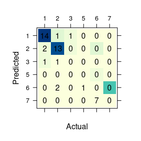

```r
# 1) construct confusion
# matrix
confusion_matrix <- cmatrix(
    actual = actual,
    predicted = predicted
)

# 2) visualize
plot(
    confusion_matrix
)
```

```r
# 3) summarize
summary(
    confusion_matrix
)
```

```
#> Confusion Matrix (6 x 6)
#> ================================================================================
#>    1  2  3  5  6  7
#> 1 14  1  1  0  0  0
#> 2  2 13  0  0  0  0
#> 3  1  1  0  0  0  0
#> 5  0  0  0  0  0  0
#> 6  0  2  0  1  0  0
#> 7  0  0  0  0  7  0
#> ================================================================================
#> Overall Statistics (micro average)
#>  - Accuracy:          0.63
#>  - Balanced Accuracy: 0.35
#>  - Sensitivity:       0.63
#>  - Specificity:       0.93
#>  - Precision:         0.63
```

### Response

We extract the response values using the `predict()`-function,

```r
# 1) prediction
# from the model
response <- predict(
        model,
        newdata = test
    )
```

The `response` can be passed into the `ROC()`-function,

```r
# 1) calculate the reciever
# operator characteristics
roc <- ROC(
    actual   = actual,
    response = response
)

# 2) print the roc
# object
print(roc)
```

```
#>    threshold level label    fpr    tpr
#> 1        Inf     1     1 0.0000 0.0000
#> 2   1.66e-15     1     1 0.0370 0.0000
#> 3   1.43e-15     1     1 0.0741 0.0000
#> 4   1.41e-15     1     1 0.1111 0.0000
#> 5   1.33e-15     1     1 0.1111 0.0625
#> 6   1.26e-15     1     1 0.1481 0.0625
#> 7   1.23e-15     1     1 0.1852 0.0625
#> 8   1.14e-15     1     1 0.2222 0.0625
#> 9   1.12e-15     1     1 0.2593 0.0625
#> 10  1.09e-15     1     1 0.2963 0.0625
#>  [ reached 'max' / getOption("max.print") -- omitted 254 rows ]
```

The `ROC()`-function returns a `data.frame`-object, with 264 rows corresponding to the `length` of `response` multiplied with number of classes in the data. The `roc`-object can be plotted as follows,

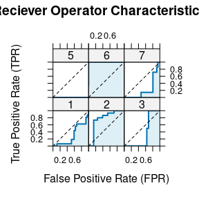

```r
# 1) plot roc
# object
plot(roc)
```

The `ROC()`-function accepts a custom `threshold`-argument, which can be passed as follows,

```r
# 1) create custom
# thresholds
thresholds <- seq(
    from = 0.9,
    to   = 0.1,
    length.out = 10
)

# 2) pass the custom thresholds
# to the ROC()-function
roc <- ROC(
    actual     = actual,
    response   = response,
    thresholds = thresholds
)

# 3) print the roc
# object
print(roc)
```

[output not shown]

The new object has 264 rows.

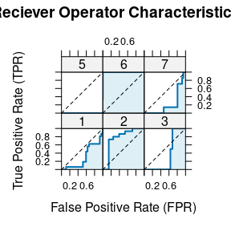

```r
# 1) viasualize
# ROC
plot(roc)
```

```r
# 1) summarise ROC
summary(roc)
```

```
#> Reciever Operator Characteristics
#> ================================================================================
#> AUC
#>  - 1: 0.303
#>  - 2: 0.765
#>  - 3: 0.341
#>  - 5: 0
#>  - 6: 0.996
#>  - 7: 0.204
```